# Module Two Problem Set: Interaction Terms and Qualitative Predictors

In this notebook, you have been given a set of steps that will show you how to create multiple regression models that include interaction terms and qualitative predictors in R. It is very important to run the steps in order. Some steps depend on the outputs of earlier steps. Once you have run all the steps, you will be asked to create your own regression models to help you answer the questions in the Module Two Problem Set. You are expected to write the R script yourself to answer these questions.

Reminder: If you have not already reviewed the Problem Set Report template for your Module Two Problem Set, be sure to do so now. That will give you an idea of the questions you will need to answer with the outputs of this script. You should use the code you are given as reference when writing your own scripts.

### Step 1: Loading the Data Set

You are an analyst working for a car maker. You have access to a set of data that can be used to study the fuel economy of a car. Car makers are interested in studying factors that are associated with better fuel economy. This data set includes several important variables that are associated with fuel economy. You will use this data set to create models to predict fuel economy.

This block of R code will load the data set from **mtcars.csv** file. Here are the variables contained in the data set.

| Variable | What does it represent? |
| --- | --- |
| mpg | Fuel economy in miles/(US) gallon |
| cyl | Number of cylinders (4, 6, 8) |
| hp | Gross horsepower |
| drat | Rear axle ratio |
| wt | Weight (1,000 lbs) |
| qsec | Quarter mile time |
| vs | Engine (0 = V-shaped, 1 = straight) |
| am | Transmission (0 = automatic, 1 = manual) |
| gear | Number of forward gears |

Reference: R data sets. (1974). *Motor trend car road tests* [Data file]. Retrieved from https://www.rdocumentation.org/packages/datasets/versions/3.6.2/topics/mtcars

Click the code section below and hit the **Run** button above.

```r
# Loading mtcars data set from a mtcars.csv file
mtcars <- read.csv(file='mtcars.csv', header=TRUE, sep=",")

# Converting appropriate variables to factors
mtcars2 <- within(mtcars, {
   vs <- factor(vs)
   am <- factor(am)
   cyl  <- factor(cyl)
   gear <- factor(gear)
   carb <- factor(carb)
})


# Print the first six rows
print("head")
head(mtcars2, 6)
```

```
[1] "head"
```

A data.frame: 6 × 12

| car <fct> | mpg <dbl> | cyl <fct> | disp <dbl> | hp <int> | drat <dbl> | wt <dbl> | qsec <dbl> | vs <fct> | am <fct> | gear <fct> | carb <fct> |
| --- | --- | --- | --- | --- | --- | --- | --- | --- | --- | --- | --- |
| Mazda RX4 | 21.0 | 6 | 160 | 110 | 3.90 | 2.620 | 16.46 | 0 | 1 | 4 | 4 |
| Mazda RX4 Wag | 21.0 | 6 | 160 | 110 | 3.90 | 2.875 | 17.02 | 0 | 1 | 4 | 4 |
| Datsun 710 | 22.8 | 4 | 108 | 93 | 3.85 | 2.320 | 18.61 | 1 | 1 | 4 | 1 |
| Hornet 4 Drive | 21.4 | 6 | 258 | 110 | 3.08 | 3.215 | 19.44 | 1 | 0 | 3 | 1 |
| Hornet Sportabout | 18.7 | 8 | 360 | 175 | 3.15 | 3.440 | 17.02 | 0 | 0 | 3 | 2 |
| Valiant | 18.1 | 6 | 225 | 105 | 2.76 | 3.460 | 20.22 | 1 | 0 | 3 | 1 |

## Step 2: Subsetting Data and Correlation Matrix

In this step, you will subset the original data set to select some variables and create a new data set. You will then print the correlation matrix for these variables in the new data set.

Click the block of code below and hit the **Run** button above.

```r
myvars <- c("mpg","wt","drat")
mtcars_subset <- mtcars2[myvars]

# Print the first six rows
print("head")
head(mtcars_subset, 6)

# Print the correlation matrix
print("cor")
corr_matrix <- cor(mtcars_subset, method = "pearson")
round(corr_matrix, 4)
```

```
[1] "head"
```

A data.frame: 6 × 3

| mpg <dbl> | wt <dbl> | drat <dbl> |
| --- | --- | --- |
| 21.0 | 2.620 | 3.90 |
| 21.0 | 2.875 | 3.90 |
| 22.8 | 2.320 | 3.85 |
| 21.4 | 3.215 | 3.08 |
| 18.7 | 3.440 | 3.15 |
| 18.1 | 3.460 | 2.76 |

```
[1] "cor"
```

A matrix: 3 × 3 of type dbl

|  | mpg | wt | drat |
| --- | --- | --- | --- |
| mpg | 1.0000 | -0.8677 | 0.6812 |
| wt | -0.8677 | 1.0000 | -0.7124 |
| drat | 0.6812 | -0.7124 | 1.0000 |

## Step 3: Multiple Regression With Interaction Term

In this step, you will create a multiple regression model for fuel economy as the response variable, and weight and rear axle ratio as predictors. A numerically higher rear axle ratio sends more of the engine's available torque to the tires, however this reduces the fuel economy. We expect that the fuel economy and weight of the car are negatively correlated, meaning that as weight decreases, the fuel economy increases. However, the rate of increase in fuel economy will be driven upward by a numerically lower rear axle ratio. This favors a multiple regression model in which the two predictor variables interact.

The general form of this regression model is:

\begin{equation*} \large E(y) = {\beta}_0\ +\ {\beta}_1\ {x}_1\ +\ {\beta}_2\ {x}_2\ +\ {\beta}_3\ {x}_1\ {x}_2 \end{equation*}

\begin{equation*} \text{where y is fuel efficiency,}\ {x}_1\ \text{is weight,}\ {x}_2\ \text{and rear axle ratio} \end{equation*}

Click the block of code below and hit the **Run** button above.

```r
# Create the multiple regression model and print summary statistics. Note that this model includes the interaction term.
model1 <- lm(mpg ~ wt + drat + wt:drat, data=mtcars_subset)
summary(model1)
```

```
Call:
lm(formula = mpg ~ wt + drat + wt:drat, data = mtcars_subset)

Residuals:
    Min      1Q  Median      3Q     Max
-3.8913 -1.8634 -0.3398  1.3247  6.4730

Coefficients:
            Estimate Std. Error t value Pr(>|t|)
(Intercept)    5.550     12.631   0.439   0.6637
wt             3.884      3.798   1.023   0.3153
drat           8.494      3.321   2.557   0.0162 *
wt:drat       -2.543      1.093  -2.327   0.0274 *
---
Signif. codes:  0 '***' 0.001 '**' 0.01 '*' 0.05 '.' 0.1 ' ' 1

Residual standard error: 2.839 on 28 degrees of freedom
Multiple R-squared:  0.7996,	Adjusted R-squared:  0.7782
F-statistic: 37.25 on 3 and 28 DF,  p-value: 6.567e-10
```

### Interpretation of Beta Estimates

Suppose the regression model is:  
\begin{equation*} \large E(y) = 5.5500\ +\ 3.8840\ {x}_1\ +\ 8.4940\ {x}_2\ -\ 2.5430\ {x}_1\ {x}_2 \end{equation*}

\begin{equation*} \text{where y is fuel efficiency,}\ {x}_1\ \text{is weight,}\ {x}_2\ \text{and rear axle ratio} \end{equation*}

**Interpret the estimated coefficient of rear axle ratio variable.**

- Let us assume there was no interaction present and the multiple regression model was 5.55 + 3.884 x1 + 8.494 x2. Then, the fuel economy of a car would increase on average by 8.494 for each unit increase in rear axle ratio (since 8.494 is the estimated coefficient for a rear axle ratio variable).
- However, weight and rear axle ratio interact in the model in step 3, therefore the rate of change of average fuel economy with rear axle ratio depends on the weight of the car. The estimated coefficient for x2 is:

  8.4940 x2 - 2.5430 (x1)(x2) = ( 8.4940 - 2.5430 x1 ) x2

  The estimated coefficient for x2 is ( 8.494 - 2.543 x1 )
- Suppose we have a car with weight 3.440. The estimated coeffficient for rear axle ratio can be calculated as:

  ( 8.494 - 2.543 x1 ) = 8.494 - 2.543 (3.440) = -0.25392

  In other words, we estimate that the fuel economy of a car with weight 3.440 will decrease by 0.25392 units for each unit increase in rear axle ratio. Note that this is different than the 8.494 from the first bullet. This is because weight and rear axle ratio interact in the multiple regression model being considered here.
- Suppose we now have a car with weight 2.32. If there were no interaction term included in the model, then the fuel economy of this car would increase on average by 8.494 for each unit increase in rear axle ratio. However, since we now have the interaction term in the model, the fuel economy of the car will increase by 8.494 - 2.543 (2.32) = 2.59 units for each unit increase in rear axle ratio.
- Therefore, the rate of increase in fuel economy now varies due to the presence of an interaction term.

## Step 4: Adding in a Qualitative Predictor

In this step, you will add a qualitative predictor into the multiple regression model from step 3. The transmission variable **am** is a qualitative variable with two levels; manual and automatic. Since this is a variable with two levels, we can use one dummy variable to represent it. R will create the dummy variable automatically and will also label it appropriately. The general form of this regression model is:  
\begin{equation*} \large E(Y) = {\beta}_0\ +\ {\beta}_1\ {x}_1\ +\ {\beta}_2\ {x}_2\ +\ {\beta}_3\ {x}_1\ {x}_2\ +\ {\beta}_4\ {x}_3 \end{equation*}

In the model above, Y is the fuel economy (mpg), x1 is weight (wt), x2 is rear axle ratio (drat), and x3 is the dummy variable for transmission (am). Note that am='1' for a manual transmission and am='0' for an automatic transmission.

Click the block of code below and hit the **Run** button above.

```r
# Subsetting data to only include the variables that are needed
myvars <- c("mpg","wt","drat","am")
mtcars_subset <- mtcars2[myvars]

# Create the model
model2 <- lm(mpg ~ wt + drat + wt:drat + am, data=mtcars_subset)
summary(model2)
```

```
Call:
lm(formula = mpg ~ wt + drat + wt:drat + am, data = mtcars_subset)

Residuals:
    Min      1Q  Median      3Q     Max
-3.6907 -1.4711 -0.2512  0.9344  6.7453

Coefficients:
            Estimate Std. Error t value Pr(>|t|)
(Intercept)    3.247     12.914   0.251   0.8034
wt             4.168      3.822   1.091   0.2851
drat           9.562      3.529   2.710   0.0116 *
am1           -1.464      1.597  -0.917   0.3674
wt:drat       -2.708      1.111  -2.438   0.0216 *
---
Signif. codes:  0 '***' 0.001 '**' 0.01 '*' 0.05 '.' 0.1 ' ' 1

Residual standard error: 2.847 on 27 degrees of freedom
Multiple R-squared:  0.8057,	Adjusted R-squared:  0.7769
F-statistic: 27.99 on 4 and 27 DF,  p-value: 2.948e-09
```

## Step 5: Fitted Values

In this step, you will obtain the fitted values of the data set using the model from step 4. Recall that the fitted value is just the predicted value of the dependent variable (miles per gallon) for data points from the data set.

Click the block of code below and hit the **Run** button above.

```r
# predicted values
print("fitted")
fitted_values <- fitted.values(model2)
fitted_values
```

```
[1] "fitted"
```

**1**

22.3202071012681

**2**

20.6895074959298

**3**

24.0747502539664

**4**

19.2785936167189

**5**

18.3566004049746

**6**

18.1948543136102

**7**

17.7829147976458

**8**

19.9455031142101

**9**

20.4155783618075

**10**

18.5453485011573

**11**

18.5453485011573

**12**

15.7244271929934

**13**

17.1343818387994

**14**

16.9270355673574

**15**

11.4830468223862

**16**

10.468474335848

**17**

9.65079623894033

**18**

25.654703888853

**19**

34.0906848946004

**20**

28.8096807794287

**21**

24.1983096753214

**22**

17.9964150947557

**23**

18.378418393557

**24**

16.124985574862

**25**

16.6489676538974

**26**

27.4785433498266

**27**

27.3857668975878

**28**

28.6890131121626

**29**

19.1154587119623

**30**

20.7842398534528

**31**

16.2835591339497

**32**

21.7238845270116

## Step 6: Residuals

In this step, you will obtain the residuals using the model in step 4. Recall that the residual is the difference between the actual value and the predicted value of the dependent variable (miles per gallon).

Click the block of code below and hit the **Run** button above.

```r
# residuals
print("residuals")
residuals <- residuals(model2)
residuals
```

```
[1] "residuals"
```

**1**

-1.32020710126808

**2**

0.310492504070191

**3**

-1.2747502539664

**4**

2.12140638328108

**5**

0.343399595025413

**6**

-0.0948543136101894

**7**

-3.48291479764585

**8**

4.45449688578988

**9**

2.38442163819248

**10**

0.654651498842696

**11**

-0.745348501157303

**12**

0.675572807006601

**13**

0.16561816120057

**14**

-1.72703556735736

**15**

-1.08304682238617

**16**

-0.068474335848017

**17**

5.04920376105967

**18**

6.74529611114699

**19**

-3.69068489460044

**20**

5.09031922057126

**21**

-2.69830967532141

**22**

-2.49641509475568

**23**

-3.17841839355699

**24**

-2.82498557486204

**25**

2.55103234610262

**26**

-0.178543349826627

**27**

-1.38576689758782

**28**

1.71098688783741

**29**

-3.31545871196233

**30**

-1.08423985345285

**31**

-1.28355913394969

**32**

-0.323884527011619

## Step 7: Diagnostic Plots — Residuals against Fitted Values

In this step, you will generate plot of residuals against fitted values to test the assumption of homoscadasticity.

Click the block of code below and hit the **Run** button above.  
NOTE: If the plot is not created, click the code section and hit the **Run** button again.

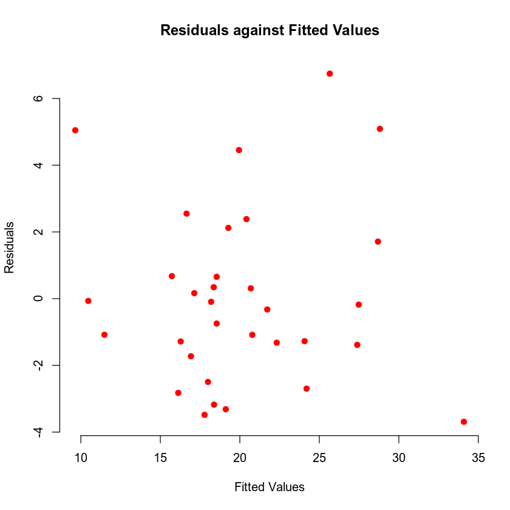

```r
plot(fitted_values, residuals,
     main = "Residuals against Fitted Values",
     xlab = "Fitted Values", ylab = "Residuals",
     col="red",
     pch = 19, frame = FALSE)
```

## Step 8: Diagnostic Plots — Q-Q Plot

In this step, you will generate a Q-Q plot to test assumptions of normality of the residuals.

Click the block of code below and hit the **Run** button above.  
NOTE: If the plot is not created, click the code section and hit the **Run** button again.

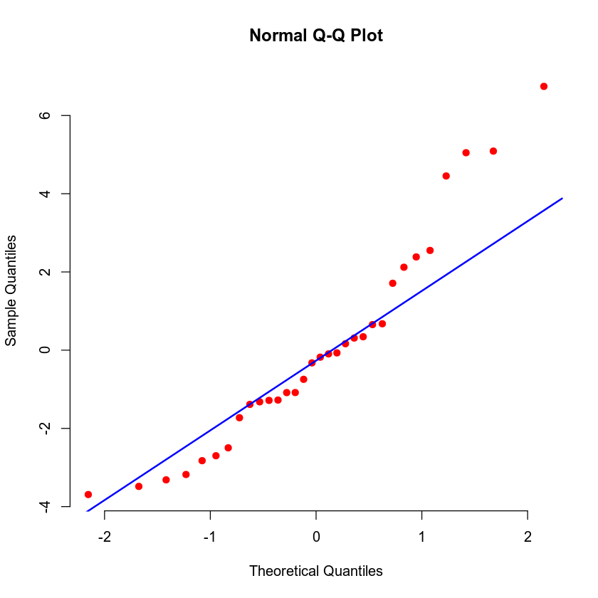

```r
qqnorm(residuals, pch = 19, col="red", frame = FALSE)
qqline(residuals, col = "blue", lwd = 2)
```

## Step 9: Confidence Interval for Parameter Estimates

In this step, you will use the **confint** function to create 90% confidence intervals for the beta parameter estimates.

Click the block of code below and hit the **Run** button above.

```r
# confidence intervals for model parameters
print("confint")
conf_90_int <- confint(model2, level=0.90)
round(conf_90_int, 4)
```

```
[1] "confint"
```

A matrix: 5 × 2 of type dbl

|  | 5 % | 95 % |
| --- | --- | --- |
| (Intercept) | -18.7488 | 25.2427 |
| wt | -2.3414 | 10.6771 |
| drat | 3.5516 | 15.5725 |
| am1 | -4.1845 | 1.2564 |
| wt:drat | -4.6004 | -0.8164 |

## Step 10: Predictions, Prediction Interval, and Confidence Interval

In this step, you will predict the fuel economy for a car that has a weight of 3.88, a rear axle ratio of 3.05, and has a manual transmission. You will also obtain a 90% prediction interval and confidence interval for this prediction. Note that this observation is not from the dataset that was used to create this model.

Click the block of code below and hit the **Run** button above.

```r
newdata <- data.frame(wt=3.88, drat=3.05, am='1')

print("prediction interval")
prediction_pred_int <- predict(model2, newdata, interval="predict", level=0.90)
round(prediction_pred_int, 4)

print("confidence interval")
prediction_conf_int <- predict(model2, newdata, interval="confidence", level=0.90)
round(prediction_conf_int, 4)
```

```
[1] "prediction interval"
```

A matrix: 1 × 3 of type dbl

| fit | lwr | upr |
| --- | --- | --- |
| 15.0672 | 9.4501 | 20.6844 |

```
[1] "confidence interval"
```

A matrix: 1 × 3 of type dbl

| fit | lwr | upr |
| --- | --- | --- |
| 15.0672 | 12.2316 | 17.9029 |

## Your Code

You have been asked to create regression models in the Module Two Problem Set. Review the Problem Set Report template to see the questions you will be answering about your models.

Use the empty blocks below to write the R code for your models and get outputs. Then use the outputs to answer the questions in your problem set report.

**Note: Use the + (plus) button to add new code blocks or the scissor icon to remove empty code blocks, if needed.**

```r
# Total number of columns in the data set
print("ncol")
ncol(mtcars2)

# Total number of rows in the data set
print("nrow")
nrow(mtcars2)
```

```
[1] "ncol"
```

12

```
[1] "nrow"
```

32

```r
# Selecting mpg, wt, hp, and drat variables to subset the data
myvars1 <- c("mpg","wt")
myvars2 <- c("mpg", "hp")
myvars3 <- c("mpg", "drat")
mtcars_mpgwt <- mtcars2[myvars1]
mtcars_mpghp <- mtcars2[myvars2]
mtcars_mpgdrat <- mtcars2[myvars3]

# Print the first 10 rows
print("head")
head(mtcars_subset, 10)

# Print the correlation matrix
print("cor")
corr_matrix <- cor(mtcars_mpgwt, method = "pearson")
round(corr_matrix, 4)

print("cor")
corr_matrix <- cor(mtcars_mpghp, method = "pearson")
round(corr_matrix, 4)

print("cor")
corr_matrix <- cor(mtcars_mpgdrat, method = "pearson")
round(corr_matrix, 4)
```

```
[1] "head"
```

[output not shown]

```
[1] "cor"
```

A matrix: 2 × 2 of type dbl

|  | mpg | wt |
| --- | --- | --- |
| mpg | 1.0000 | -0.8677 |
| wt | -0.8677 | 1.0000 |

```
[1] "cor"
```

A matrix: 2 × 2 of type dbl

|  | mpg | hp |
| --- | --- | --- |
| mpg | 1.0000 | -0.7762 |
| hp | -0.7762 | 1.0000 |

```
[1] "cor"
```

A matrix: 2 × 2 of type dbl

|  | mpg | drat |
| --- | --- | --- |
| mpg | 1.0000 | 0.6812 |
| drat | 0.6812 | 1.0000 |

```r
myvarsFIN <- c("mpg","wt","hp", "drat")
mtcars_subset <- mtcars2[myvarsFIN]

# Create the multiple regression model and print summary statistics. Note that this model includes the interaction term.
model1 <- lm(mpg ~ wt + hp + drat + wt:hp + wt:drat, data=mtcars_subset)
summary(model1)
```

```
Call:
lm(formula = mpg ~ wt + hp + drat + wt:hp + wt:drat, data = mtcars_subset)

Residuals:
    Min      1Q  Median      3Q     Max
-3.5677 -1.1158 -0.3189  1.3662  4.0876

Coefficients:
             Estimate Std. Error t value Pr(>|t|)
(Intercept)  75.68431   23.17119   3.266  0.00306 **
wt          -16.12967    6.84348  -2.357  0.02624 *
hp           -0.16480    0.04632  -3.558  0.00146 **
drat         -5.44987    4.72118  -1.154  0.25886
wt:hp         0.04069    0.01358   2.995  0.00595 **
wt:drat       1.70650    1.43301   1.191  0.24447
---
Signif. codes:  0 '***' 0.001 '**' 0.01 '*' 0.05 '.' 0.1 ' ' 1

Residual standard error: 2.175 on 26 degrees of freedom
Multiple R-squared:  0.8907,	Adjusted R-squared:  0.8697
F-statistic: 42.39 on 5 and 26 DF,  p-value: 1.092e-11
```

```r
# predicted values
print("fitted")
fitted_values <- fitted.values(model1)
fitted_values
```

```
[1] "fitted"
```

**1**

23.2057719374347

**2**

21.9311617438639

**3**

25.9766565564915

**4**

20.2017419216761

**5**

17.1778690128496

**6**

18.608877941059

**7**

15.3763876998252

**8**

22.0379416633372

**9**

21.1045098393052

**10**

18.7926746086807

**11**

18.7926746086807

**12**

14.7731447060571

**13**

15.9857832392063

**14**

15.8074540431549

**15**

11.2937994989425

**16**

11.6340817376464

**17**

13.4474744497594

**18**

28.3123748041894

**19**

31.2015495460171

**20**

30.4437279496486

**21**

25.0677093610857

**22**

17.2092741877615

**23**

17.8218156545136

**24**

15.7656171944836

**25**

15.6284840547416

**26**

30.0300117840897

**27**

26.1288754370153

**28**

28.8022022201765

**29**

14.9283769793236

**30**

19.2725693674714

**31**

13.8299277836953

**32**

22.3094784678164

```r
# residuals
print("residuals")
residuals <- residuals(model1)
residuals
```

```
[1] "residuals"
```

**1**

-2.20577193743468

**2**

-0.931161743863905

**3**

-3.17665655649146

**4**

1.19825807832385

**5**

1.52213098715043

**6**

-0.508877941059012

**7**

-1.07638769982524

**8**

2.36205833666277

**9**

1.69549016069476

**10**

0.407325391319262

**11**

-0.992674608680736

**12**

1.62685529394293

**13**

1.31421676079371

**14**

-0.607454043154942

**15**

-0.893799498942536

**16**

-1.23408173764643

**17**

1.2525255502406

**18**

4.08762519581055

**19**

-0.801549546017109

**20**

3.45627205035145

**21**

-3.56770936108574

**22**

-1.70927418776154

**23**

-2.62181565451356

**24**

-2.4656171944836

**25**

3.57151594525835

**26**

-2.73001178408967

**27**

-0.128875437015288

**28**

1.59779777982347

**29**

0.871623020676437

**30**

0.427430632528615

**31**

1.17007221630468

**32**

-0.909478467816422

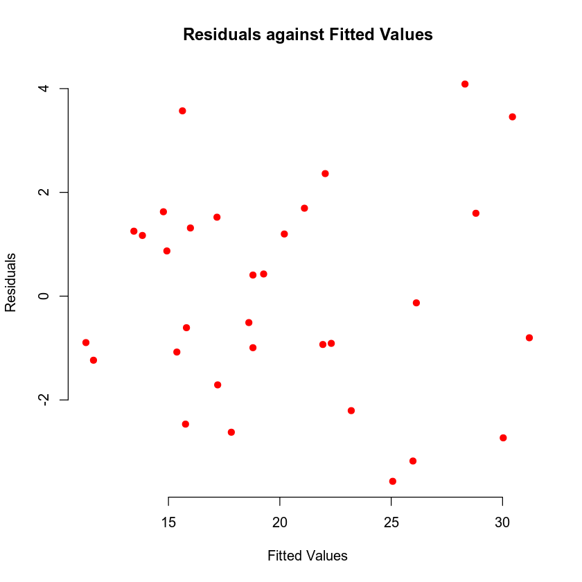

```r
plot(fitted_values, residuals,
     main = "Residuals against Fitted Values",
     xlab = "Fitted Values", ylab = "Residuals",
     col="red",
     pch = 19, frame = FALSE)
```

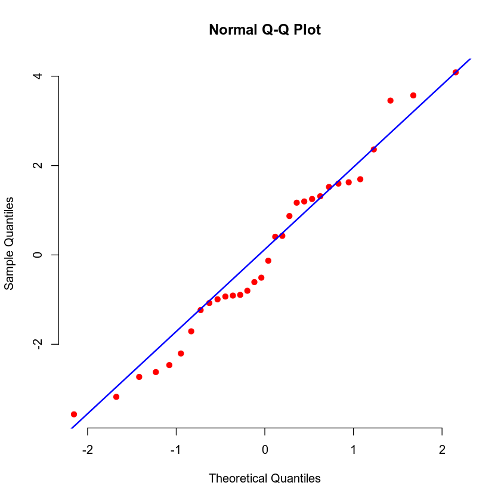

```r
qqnorm(residuals, pch = 19, col="red", frame = FALSE)
qqline(residuals, col = "blue", lwd = 2)
```

```r
anova(model1)
```

A anova: 6 × 5

|  | Df <int> | Sum Sq <dbl> | Mean Sq <dbl> | F value <dbl> | Pr(>F) <dbl> |
| --- | --- | --- | --- | --- | --- |
| wt | 1 | 847.725250 | 847.725250 | 179.121219 | 3.597502e-13 |
| hp | 1 | 83.274183 | 83.274183 | 17.595528 | 2.809222e-04 |
| drat | 1 | 11.365868 | 11.365868 | 2.401566 | 1.333018e-01 |
| wt:hp | 1 | 53.920449 | 53.920449 | 11.393192 | 2.324591e-03 |
| wt:drat | 1 | 6.711491 | 6.711491 | 1.418113 | 2.444731e-01 |
| Residuals | 26 | 123.049947 | 4.732690 | NA | NA |

```r
new <- data.frame(wt = 2.965, hp = 210, drat = 2.91)
predict(model1, newdata=new, interval = "confidence", level = 0.95)
predict(model1, newdata=new, interval = "prediction", level = 0.95)
```

A matrix: 1 × 3 of type dbl

| fit | lwr | upr |
| --- | --- | --- |
| 17.45198 | 15.20236 | 19.70159 |

A matrix: 1 × 3 of type dbl

| fit | lwr | upr |
| --- | --- | --- |
| 17.45198 | 12.44625 | 22.45771 |

```r
myvarsFINQ <- c("mpg","wt","hp", "cyl")
mtcars_subsetQ <- mtcars2[myvarsFINQ]

# Create the multiple regression model and print summary statistics. Note that this model includes the interaction term and Qualitative Predictor.
model2 <- lm(mpg ~ wt + hp + wt:hp + cyl, data=mtcars_subsetQ)
summary(model2)
```

```
Call:
lm(formula = mpg ~ wt + hp + wt:hp + cyl, data = mtcars_subsetQ)

Residuals:
    Min      1Q  Median      3Q     Max
-3.5309 -1.6451 -0.4154  1.3838  4.4788

Coefficients:
             Estimate Std. Error t value Pr(>|t|)
(Intercept) 47.337329   4.679790  10.115 1.67e-10 ***
wt          -7.306337   1.675258  -4.361 0.000181 ***
hp          -0.103331   0.031907  -3.238 0.003274 **
cyl6        -1.259073   1.489594  -0.845 0.405685
cyl8        -1.454339   2.063696  -0.705 0.487246
wt:hp        0.023951   0.008966   2.671 0.012865 *
---
Signif. codes:  0 '***' 0.001 '**' 0.01 '*' 0.05 '.' 0.1 ' ' 1

Residual standard error: 2.203 on 26 degrees of freedom
Multiple R-squared:  0.888,	Adjusted R-squared:  0.8664
F-statistic: 41.21 on 5 and 26 DF,  p-value: 1.503e-11
```

```r
# predicted values
print("fitted")
fitted_values <- fitted.values(model2)
fitted_values
```

```
[1] "fitted"
```

**1**

22.4719647039527

**2**

21.2806803222005

**3**

25.9445425422249

**4**

19.6923011465309

**5**

17.0848657864151

**6**

18.6500337126298

**7**

15.4321575884351

**8**

22.360653229631

**9**

21.6733073873789

**10**

18.3689607794725

**11**

18.3689607794725

**12**

15.0932459234055

**13**

16.1115863071822

**14**

15.9618303683915

**15**

12.1193228375994

**16**

11.9681618658067

**17**

12.5088718698325

**18**

27.9212471121855

**19**

32.1757972786585

**20**

30.0704560012677

**21**

25.0309400634222

**22**

17.3112485522001

**23**

17.6269092329899

**24**

15.0438192499619

**25**

15.8233414824801

**26**

29.4385196341241

**27**

26.9628910254845

**28**

28.7013341186829

**29**

15.4867628093107

**30**

19.367098555741

**31**

13.8278761259895

**32**

23.0203116069397

```r
# residuals
print("residuals")
residuals <- residuals(model2)
residuals
```

```
[1] "residuals"
```

**1**

-1.47196470395267

**2**

-0.280680322200477

**3**

-3.14454254222491

**4**

1.70769885346905

**5**

1.61513421358492

**6**

-0.550033712629825

**7**

-1.13215758843506

**8**

2.03934677036896

**9**

1.12669261262108

**10**

0.831039220527462

**11**

-0.568960779472536

**12**

1.30675407659455

**13**

1.18841369281781

**14**

-0.761830368391496

**15**

-1.71932283759936

**16**

-1.56816186580674

**17**

2.19112813016749

**18**

4.47875288781455

**19**

-1.77579727865849

**20**

3.8295439987323

**21**

-3.53094006342225

**22**

-1.81124855220007

**23**

-2.42690923298991

**24**

-1.74381924996186

**25**

3.37665851751994

**26**

-2.13851963412409

**27**

-0.962891025484538

**28**

1.69866588131708

**29**

0.313237190689267

**30**

0.332901444258993

**31**

1.17212387401052

**32**

-1.62031160693969

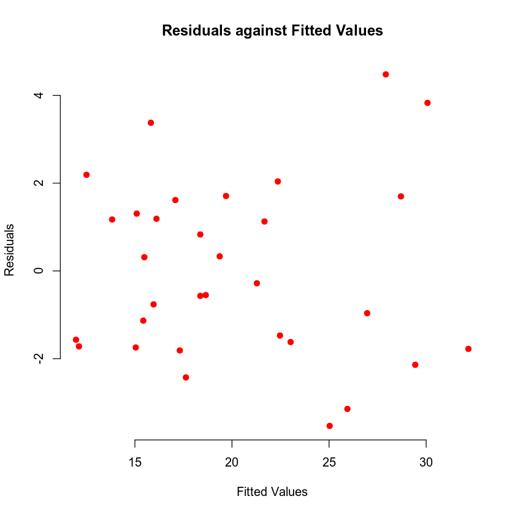

```r
plot(fitted_values, residuals,
     main = "Residuals against Fitted Values",
     xlab = "Fitted Values", ylab = "Residuals",
     col="red",
     pch = 19, frame = FALSE)
```

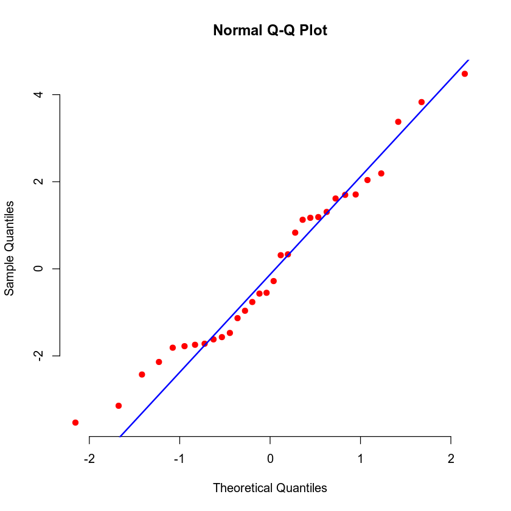

```r
qqnorm(residuals, pch = 19, col="red", frame = FALSE)
qqline(residuals, col = "blue", lwd = 2)
```

```r
anova(model2)
```

A anova: 5 × 5

|  | Df <int> | Sum Sq <dbl> | Mean Sq <dbl> | F value <dbl> | Pr(>F) <dbl> |
| --- | --- | --- | --- | --- | --- |
| wt | 1 | 847.72525 | 847.725250 | 174.712395 | 4.778726e-13 |
| hp | 1 | 83.27418 | 83.274183 | 17.162438 | 3.219041e-04 |
| cyl | 2 | 34.27012 | 17.135060 | 3.531460 | 4.397623e-02 |
| wt:hp | 1 | 34.62255 | 34.622552 | 7.135554 | 1.286452e-02 |
| Residuals | 26 | 126.15508 | 4.852119 | NA | NA |

```r
new <- data.frame(wt = 2.965, hp = 210, cyl = "6")
predict(model2, newdata=new, interval = "confidence", level = 0.95)
predict(model2, newdata=new, interval = "prediction", level = 0.95)
```

A matrix: 1 × 3 of type dbl

| fit | lwr | upr |
| --- | --- | --- |
| 17.62864 | 14.99039 | 20.26689 |

A matrix: 1 × 3 of type dbl

| fit | lwr | upr |
| --- | --- | --- |
| 17.62864 | 12.38827 | 22.86902 |

## End of Module Two Jupyter Notebook

Attach the HTML output along with your problem set report for the Module Two Problem Set. The HTML output can be downloaded by clicking **File**, then **Download as**, then **HTML**. Be sure to answer all of the questions in your problem set report.